# Campaign Contributions EDA Project

## Date/Candidate Receipts

### Date/All Candidates

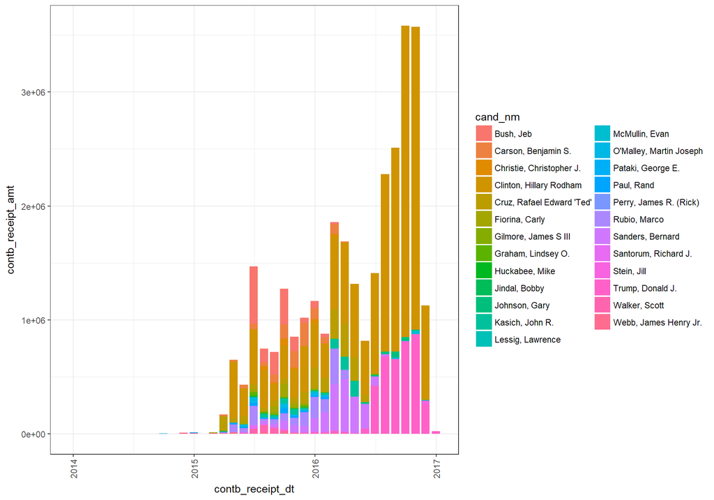

### Date/Top 5 Candidates

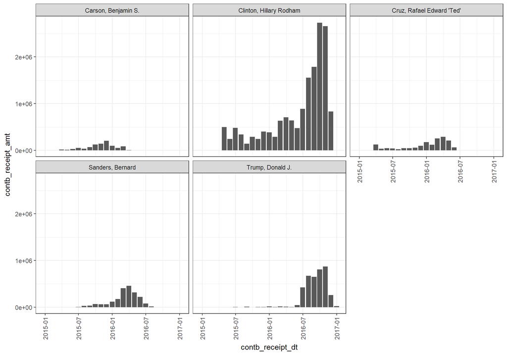

It’s interesting to clearly see the switch in funding after the Primary Election was finished. After Donald Trump won the Primary, his contribution receipts jumped substantially. The effect was even greater for Hillary Clinton. Also worth noting is the increase in funds does not look like just a shift from the other candidates. It seems that contributors give higher amounts after each party’s candidate is selected.

### Date/Polical Parties

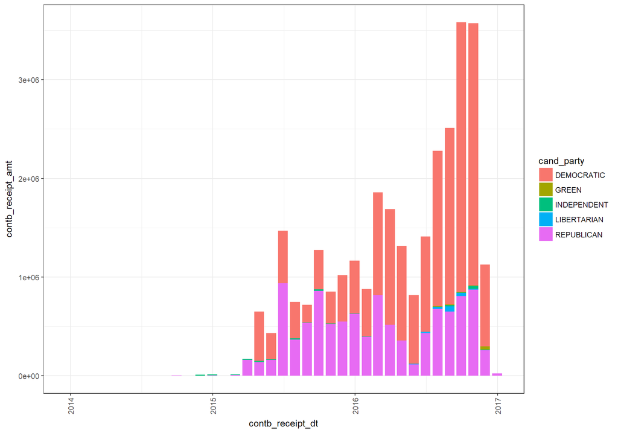

The timeline for the contributions to each party have roughly two peaks. The first is some time around early 2016, possibly due to candidates dropping out of the race and the uncertainty that creates for potential contributors. Then the next peak is around the General Election day.

### Date/Party/Candidates

#### Democrats

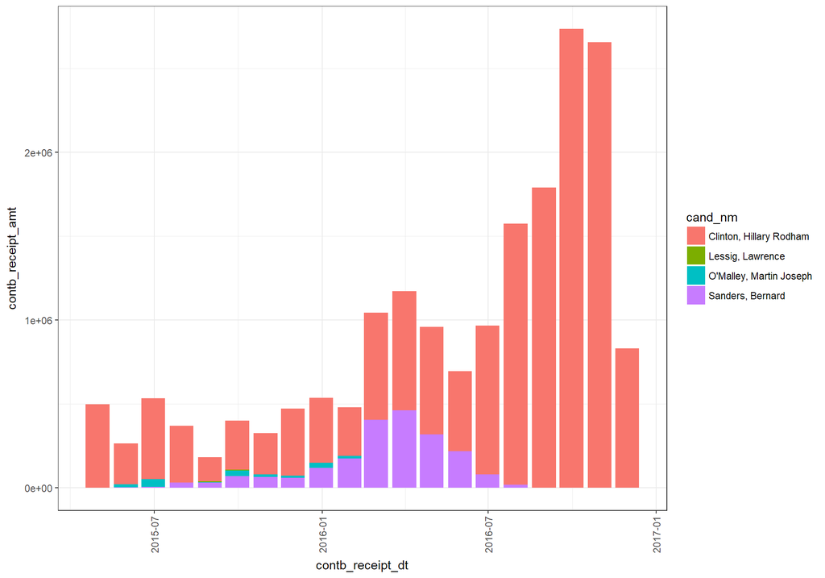

#### Republicans

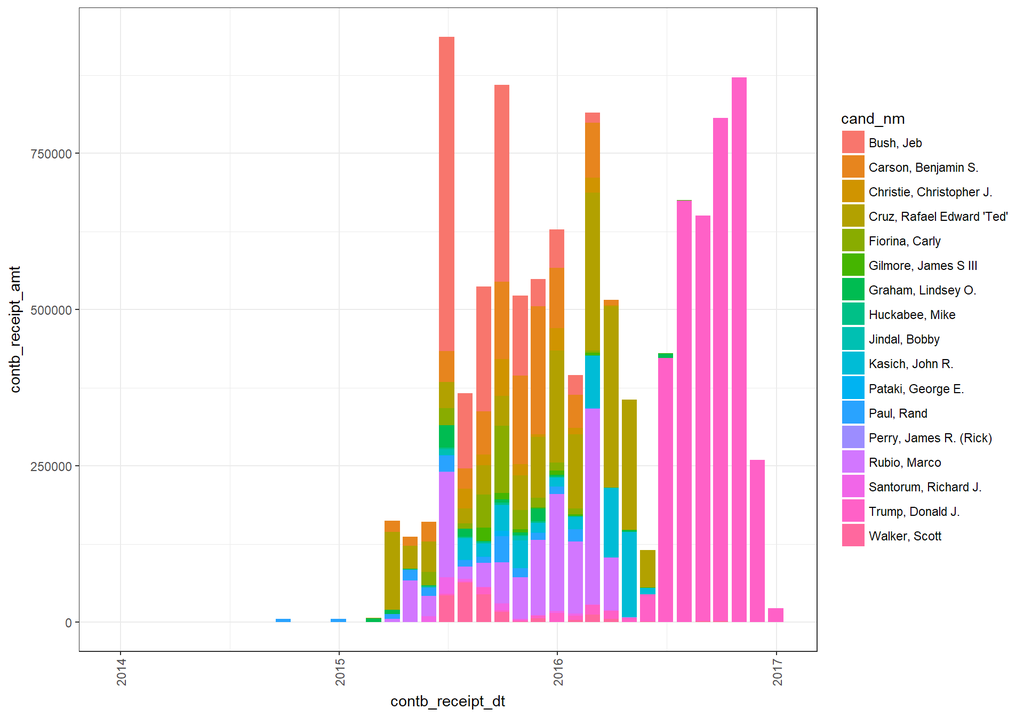

The parties adopted quite different strategies for their election process. The Democratic had 4 candidates to the 17 Republican candidates. The Democratic chart looks like it Hillary was always going to be the Democratic nominee. The Republican chart has a lot of variability in the candidate with the most contributions until after the Primary election was completed. However, this dataset only represents the population that contributed the candidates, and there might not be any correlation between this population and the general voting population.

# Multivariate Analysis

Looking at the data through a temporal lense seems to be most interesting. The trend of contribution during this election have 2 peaks. This is evident for both parties in varying degrees. The first peak is associated with the buildup to the parties’ Primary Elections. The second peak is associated with the General Election. The Democratic party seems to have a more stable Primary Election phase, with only a few possible candidates to choose. The Republican party has a more open nominee selection process.

Separating the candidates into their own graphs gives a much clearer picture of the difference between the funding provided to each candidate. As a broader theme, the amount of funding a candidate receives does not seems to closely match with the way people actually vote. Several of the results of the Virginia elections do not match what we see in these charts.

# Final Plots and Summary

## Plot One

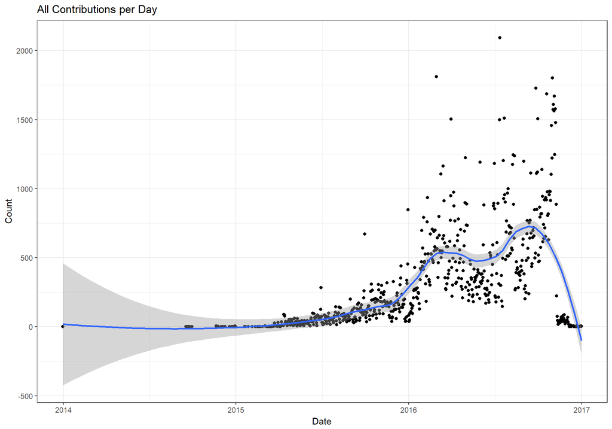

## Description One

This plot shows the contribution frequency by date for the election period. The local regression line provides a nice trend line for the counts. Most of the data instances are dated after early 2015. The confidence interval around the trend line quickly shrunk after the rate of contribution increased in early 2015.

## Plot Two

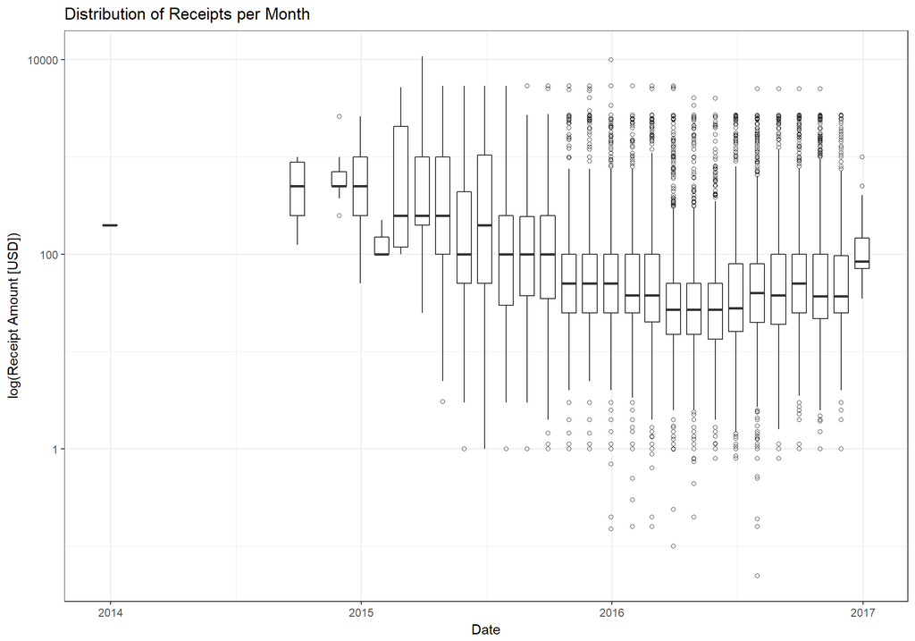

## Description Two

This boxplot of receipts per month shows a difference between the contributions that the candidates got throughout the election process. Both the mean and the median is relatively high earlier in the election. As the candidates get further into the election, the mean and median condibution receipt amount decreases until the late election. A lot more “outliers” are observed during the most active months of the election. While they might be interesting to investigate further, I do not think most of these values are outliers because of errors.

## Plot Three

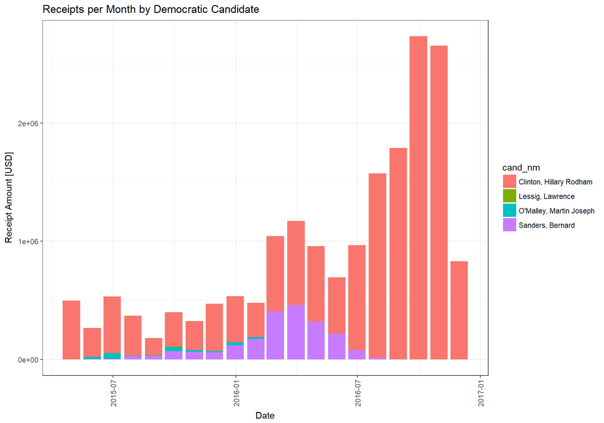

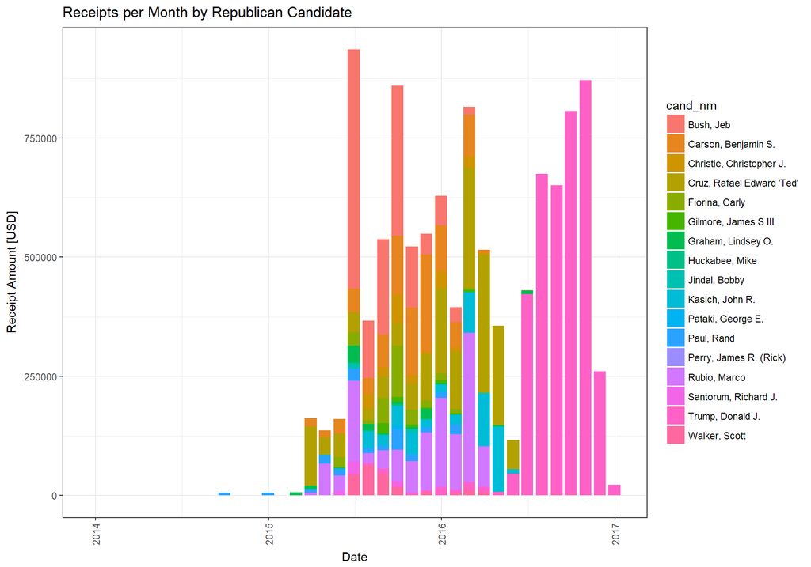

## Description Three

While this is two plots, they are interrelated. The difference between and within the candidates is the most important aspect of this dataset. On the Democrats side Hillary Clinton had more funding throughout the whole election cycle in Virginia. Also, the competition was mostly between Hillary Clinton and Bernie Sanders. The Republican side looks very different. There were many more candidates represented in the election, and it was not evident who was the favorite until after the Primary Election. These plots together provide a clear distinction between the Republican and Democratic Primary election more than the General election.

# Reflection

In my exploration of the 2016 US presidential election in Virginia dataset, I always thought something was missing.

For this exploration, I decided that looking at the features that seemed most likely to be interesting. There are features that have a very specific accounting or compliance purpose. There are features that serve an indentification purpose, such as contributor names. I chose to just skip features that had a compliance purpose or could not be even partially generalizable. I had to create a feature for the candidates’ party and committee names. I used the Federal Election Commission website to find the candidates’ parties and committee names by ID. A short python script created the features and export a new csv.

Most of the features I used can have misspellings and missing values or are completely misleading. If I was planning to do more work on this dataset, I would have put much more effort into fixing the misspelling. Like I mentioned in the exploration, the effort to benefit ratio will constitute how much time should be allocated to cleaning the dataset. Figuring out how to deal with missing values or impossible values (e.g. Hong Kong for city) is more difficult and would depend on the use case. In most cases, I would think that missing values should just be removed from analysis since most of the time we are dealing with contributors’ free-text answers. However, creating new features for contributors’ demographics might have some insightful results. This could be things like contibutors’ occupation industry rather than specific occupation or residential counties rather cities or zipcode.

I think my greatest challenge was understanding what this dataset actually represents. Throughout the exploration I wanted to consider how these features could explain the results of the 2016 election in Virginia. However, making that leap would require certain assumptions or insights about how people contribute to elections versus how they actually vote. I think that’s a very interesting topic to explore, but I doubt this dataset alone would provide a sufficient or generalizable explanation. This dataset only explains how people contributed in Virginia in during the 2016 election.